# Palmer Archipelago penguins

- Show All Code
- Hide All Code
- View Source

Author

39123456

Published

August 25, 2023

```r
knitr::opts_chunk$set(echo = TRUE)
library(palmerpenguins)
library(tidyverse)
library(ggplot2)
library(patchwork)
library(ggpubr)
# creates a file with the bibtex for packages used:
knitr::write_bib(c(.packages(),
                   "knitr", "rmarkdown"), "refs/packages.bib")
# extra bibliography for manually added references bibliography.bibtex
```

## 1 Introduction

### 1.1 Data Wrangling

The calculations in this report were performed in R (R Core Team 2023) within the Rmarkdown environment (Xie, Allaire, and Grolemund 2018) for reproducibility. Data wrangling was performed in base R and the tidyverse (Wickham et al. 2019). Graphs were produced with ggplot2 (Wickham et al. 2019) except for the QQ plots which were made with the ggpubr package (Kassambara 2023). Additional figure manipulation was performed with patchwork (Pedersen 2022).

Names of the variables were cleaned and shortened. Missing values were not removed at this stage, but will dealt with on a case by case basis, to conserve as much data as possible.

```r
data(penguins, package = 'palmerpenguins')
#head(penguins_raw)
penguins <- penguins_raw
old_names = colnames(penguins_raw)
penguins = penguins_raw %>%
  janitor::clean_names()

penguins$species <- as.factor(penguins$species)
levels(penguins$species) <- c("Adelie","Chinstrap","Gentoo")
myPalette <- c("darkorange","purple","cyan4")
names(myPalette)   <- levels(penguins$species)
```

## 2 Results

### 2.1 Is flipper length significantly different at the p < 0.05 level between *Adelie* and *Chinstrap* penguins?

In the left panel of Figure 2 flipper length can be seen to be roughly proportional to body mass. The distribution of flipper lengths is shown as a histogram on the right of Figure 2. To test if flipper length is the same for *Adelie* and *Chinstrap* penguins, we perform a two sample t-test of the two means.

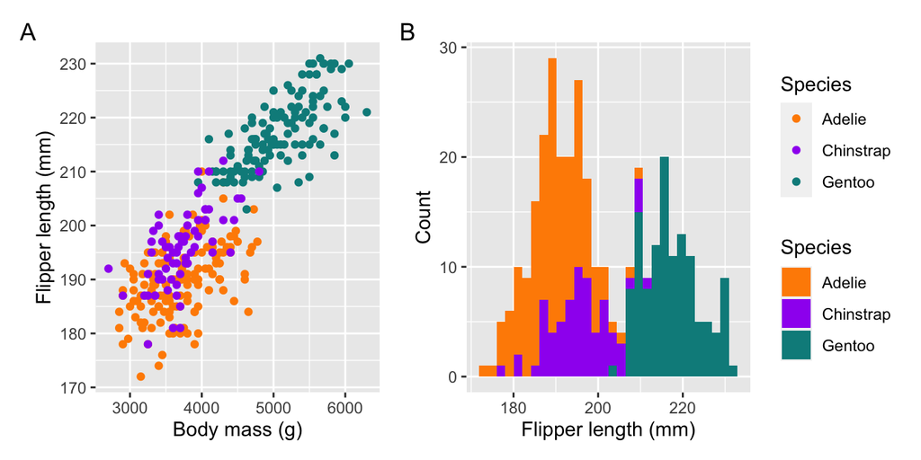

Figure 2: Aspects of flipper length for all three species studied. **A**: Flipper length vs body mass **B**: Histogram of flipper length

```r
p1 <-  ggplot(penguins) +
  # add the aesthetics
  aes(x = body_mass_g,
      y = flipper_length_mm,
      colour = species) +
  # add a geometry
  geom_point() +

  scale_color_manual(values = myPalette) +
  # tidy up the labels
  labs(x = "Body mass (g)",
       y = "Flipper length (mm)",
       colour = "Species")


p2 <- ggplot(penguins) +
  # add the aesthetics
  aes(x = flipper_length_mm,
      fill = species) +
  # add a geometry
  geom_histogram() +
  scale_fill_manual(values = myPalette)  +
  labs(x = "Flipper length (mm)", y = "Count", fill = "Species")

p1  + p2 + plot_layout(guides = 'collect') +
  plot_annotation(tag_levels = 'A')
```

```r
formatted = penguins %>% select(flipper_length_mm, species) %>% group_by(species)  %>% drop_na() %>%
  summarise(n = n(),
            Mean = mean(flipper_length_mm) %>% signif(2),
            SD = sd(flipper_length_mm) %>% signif(2)
            )
knitr::kable(formatted)
```

Table 1: Flipper length in Palmer Island penguin species.

| species | n | Mean | SD |
| --- | --- | --- | --- |
| Adelie | 151 | 190 | 6.5 |
| Chinstrap | 68 | 200 | 7.1 |
| Gentoo | 123 | 220 | 6.5 |

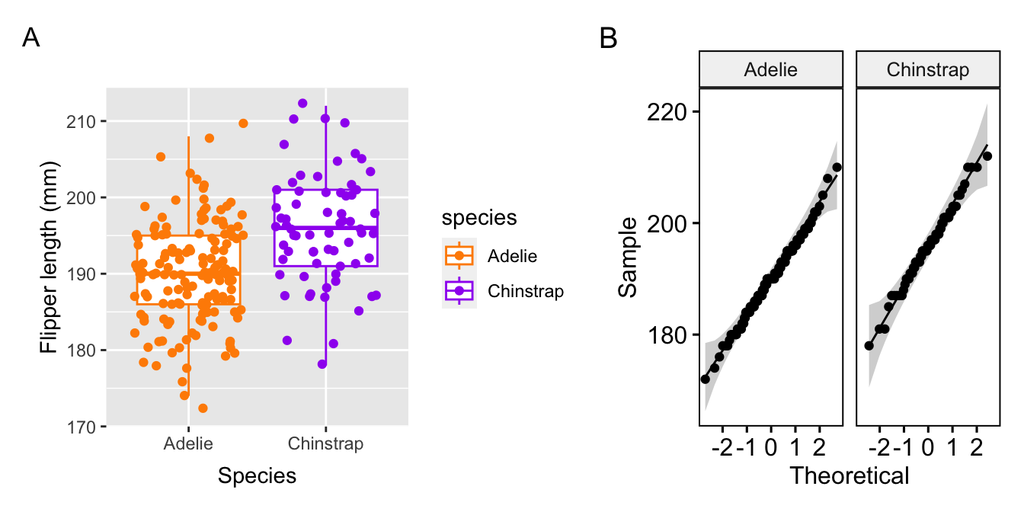

Figure 3: Sidde by side boxplots showing approximately equal spread of flipper length across Adelie and Chinstrap with corresponding QQ plots

```r
penguins %>% filter(species != "Gentoo") %>%
  group_by(species)  %>%
  select(c(species, flipper_length_mm)) %>%
  drop_na() -> mydata

p1 <-  ggplot(mydata,aes(x = species, y = flipper_length_mm, colour = species)) +
  geom_boxplot(outlier.shape = NA) + #remove outliers so not confused with jitter
  geom_jitter() +
  scale_color_manual(values = myPalette[c(1:2)])   +
  labs(y = "Flipper length (mm)", x = "Species")

p2 <-  ggqqplot(mydata, x = "flipper_length_mm", facet.by = "species")

p1 + p2 + plot_annotation(tag_levels = 'A')
```

```r
penguins$flipper_length_mm[penguins$species %in% "Adelie"] -> fl_a
penguins$flipper_length_mm[penguins$species %in% "Chinstrap"] -> fl_c
myTest <- t.test(fl_a, fl_c, var.equal = TRUE)
```

1. **Hypothesis**: Let $\mu_A$ and $\mu_C$ be the population mean flipper lengths for *Adelie* and *Chinstrap* penguins respectively. $H_0$: $\mu_A$ = $\mu_C$ vs $H_1$: $\mu_A \ne \mu_C$
2. **Assumptions**: The two populations are normally distributed (the points are all reasonably close to the line in the QQ plot in the right panel of Figure 3) and have roughly equal variances (the estimated standard deviations are quite similar in Table 1 and the spreads look similar in the boxplots in Figure 3).
3. **Test statistic**: $T = \frac{\bar{X}_A - \bar{X}_C}{S_p \sqrt{\frac{1}{n_A} + \frac{1}{n_C}}}\sim t_{n_A+n_B-2}$ where $n_A =$ 151, $n_C =$ 68 and $S_p = \sqrt{\frac{(n_A-1)S^2_A + (n_C-1)S^2_C}{n_A + n_C-2}}$.
4. **Observed test statistic**: $t_0$ = -5.97
5. **p-value**: $2P(t_{217} \le -5.97) <0.001$
6. **Decision**: Since the p-value is less than 0.05, we reject the null hypothesis and conclude there is a significant difference in the mean flipper lengths between these two species.

The culmen is the upper ridge of a bird’s bill. Figure 4 shows that the culmen is roughly proportional to body mass for Adelie and Gentoo penguins. Chinstrap penguins tend to have longer beaks.

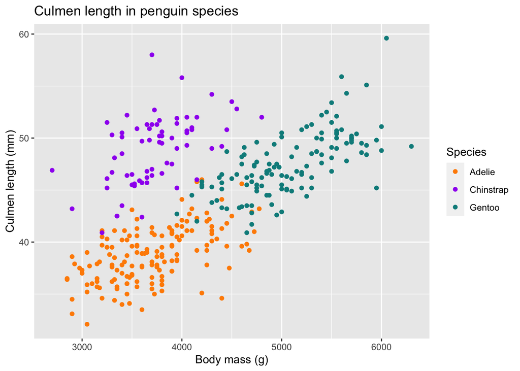

Figure 4: Culmen length against body mass for the three species of penguin.

```r
penguins %>%
  ggplot() +
  # add the aesthetics
  aes(x = body_mass_g,
      y = culmen_length_mm,
      colour = species) +
  # add a geometry
  geom_point() +
  scale_color_manual(values = myPalette) +
  # tidy up the labels
  labs(x = "Body mass (g)",
       y = "Culmen length (mm)",
       colour = "Species") +
  ggtitle("Culmen length in penguin species")
```

First, we check the assumptions.

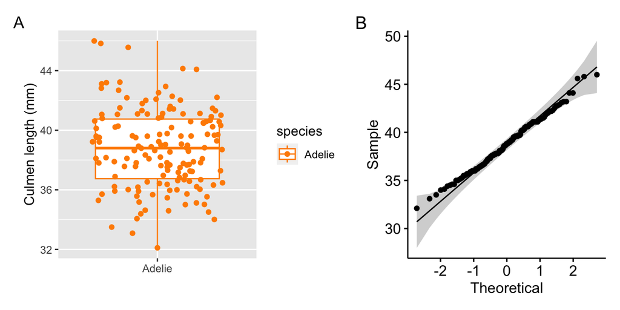

Figure 5: A boxplot showing a symmetric distribution for the culment lengths of Adelie penguins and a corresponding QQ plot where the points are all close to the line consistent with what we would expect to see when sampling from a normal population.

```r
penguins %>% filter(species == "Adelie") %>%
  group_by(species)  %>%
  select(c(species, culmen_length_mm)) %>%
  drop_na() -> mydata

p1 <-  ggplot(mydata,aes(x = species, y = culmen_length_mm, colour = species)) +
  geom_boxplot(outlier.shape = NA) + #remove outliers so not confused with jitter
  geom_jitter() +
  scale_color_manual(values = myPalette)  +
  labs(y = "Culmen length (mm)", x = "")

p2 <-  ggqqplot(mydata, x = "culmen_length_mm")

p1  + p2 + plot_annotation(tag_levels = 'A')
```

- **Hypothesis:** $H_0: \mu = 40.0$ mm vs $H_1 :\mu < 40.0$ mm
- **Assumptions:** Observations $X_i$ are iid $N(\mu,\sigma^2)$ random variables. Culmen lengths in Adelie penguins do appear to be normally distributed (the points are close to the straight line in Figure 5)
- **Test statistic:** $T = \frac{\bar{X} − \mu_0}{S/\sqrt{n}}$. Under $H_0, T \sim t_{n-1}$.

```r
t0 <- t.test(mydata$culmen_length_mm, mu = 40.0, alternative = "less")
```

- **Observed test statistic:** $t_0 =$ -5.58 with 150 degrees of freedom
- **p-value**: $P(t_{150} \le -5.58) <0.001$
- **Decision**: Reject in $H_0$ favour of $H_1$, as the observed test statistic, -5.58, is smaller than the critical value of -1.66. The data supports scientists’ belief that the culmen length for the Palmer Archipelago Adelie penguins is less than 40mm.

### 2.3 Are the genders equally split in penguin species?

The bar chars in Figure 6 show that the sexes of all 3 penguin species look like they are split evenly, but to test this formally we do a chi-square test for homogeneity of sex across the three species. [Note that in doing a test for homogeneity we have assumed that the researchers went out and deliberately sampled a from each species (population).]

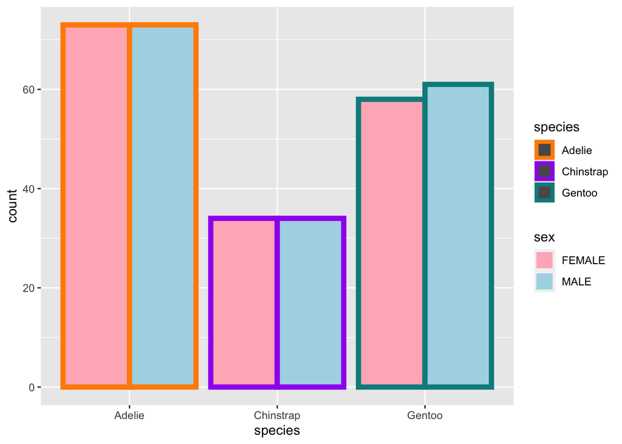

Figure 6: Distribution of sexes in penguin species surveyed

```r
penguins %>% select(species, sex) %>%  drop_na() %>%
  ggplot(aes(species))  +
  geom_bar(aes(fill = sex, colour = species), position = "dodge", linewidth = 2) +
  scale_fill_manual(values = c("lightpink","lightblue")) +
  scale_color_manual(values = myPalette)
```

```r
set.seed(1)
chiqMF <-  chisq.test(table(penguins$sex,penguins$species))
chiqMF_sim <-  chisq.test(table(penguins$sex,penguins$species), simulate.p.value = TRUE)
```

1. **Hypotheses**: $H_0$: The proportion of males and females is the same across each species of penguins. $H_1$: The gender ratio is not the same for one or more species.
2. **Assumptions**: researchers sampled the penguins randomly from each species and did not enroll matched numbers of each sex. $e_i$ = $np_i \ge 5$, which we have checked and confirmed to be TRUE.
3. **Test statistic**: $T = \sum_i^k \frac{(Y_i - e_i)^2}{e_i} \sim \chi^2_2$.
4. **Observed test statistic**: $t_0$ = 0.049
5. **p-value**: $P(\chi^2_2 \ge$ 0.049 ) = 0.976
6. **Decision**: Since the p-value is close to 1, we do not reject the null hypothesis. The distribution of the two sexes is not significantly different across the penguin species.

While not necessary in this case, because the assumptions were met, we could also have performed the test using a simulation based approach and obtained a similarly large p-value of 0.976.

## 3 Conclusion

Penguins are threatened species in the Antarctic. This study on the penguins of the Palmer archipelago aims to monitor changes in penguin populations over time.

Here we showed that there was a significant difference in the flipper length between Adelie and Chinstrap penguins.

However culmen length of Adelie penguins on the Palmer peninsula is significantly shorter than that found in a previous study for Adelie penguins on the Antarctic mainland. We hope to investigate whether this is due to genetic or environmental factors on our subsequent return to the Palmer peninsula if further grant funding is successful.

The proportion of male and female penguins was found to be the same across the three species.

## 4 References

Horst, Allison Marie, Alison Presmanes Hill, and Kristen B Gorman. 2020. *Palmerpenguins: Palmer Archipelago (Antarctica) Penguin Data*. https://allisonhorst.github.io/palmerpenguins/.

Kassambara, Alboukadel. 2023. *Ggpubr: Ggplot2 Based Publication Ready Plots*. https://rpkgs.datanovia.com/ggpubr/.

Pedersen, Thomas Lin. 2022. *Patchwork: The Composer of Plots*. https://CRAN.R-project.org/package=patchwork.

R Core Team. 2023. *R: A Language and Environment for Statistical Computing*. Vienna, Austria: R Foundation for Statistical Computing. https://www.R-project.org/.

Wickham, Hadley, Mara Averick, Jennifer Bryan, Winston Chang, Lucy D’Agostino McGowan, Romain François, Garrett Grolemund, et al. 2019. “Welcome to the tidyverse.” *Journal of Open Source Software* 4 (43): 1686. https://doi.org/10.21105/joss.01686.

Xie, Yihui, J. J. Allaire, and Garrett Grolemund. 2018. *R Markdown: The Definitive Guide*. Boca Raton, Florida: Chapman; Hall/CRC. https://bookdown.org/yihui/rmarkdown.